# Project 3 - Traffic Data vs Immigration and Population Change for U.S. Cities

Daniel Schlomer, Jesse Pye

October 2, 2015"

```r
require("jsonlite")
require("RCurl")
require("extrafont")
```

```r
require("ggplot2")
require("dplyr")
```

This is an html file that documents the steps to reproduce our project . This html file presents a visual story about our data and what we discovered about our data using visualization and workflow techniques.

The first thing we did was locate a source of data. We used our traffic data from our last project. In addition, we found new data - we located census data describing population changes in U.S. urban areas from 2010-2014 due to births, deaths, domestic migration, and international immigration. We had to extract, transform, and load this data into an Oracle database.

Now, let’s do some workflows and visualize our data!

First, we did an inner join over the two sets of data. Using the data, we plotted net migration (per capita) vs. commuter delay. From the data, you can see a weak positive correlation between net immigration and commuter delay.

```
##
## > require("jsonlite")
##
## > require("RCurl")
##
## > require("extrafont")
##
## > require("ggplot2")
##
## > require("dplyr")
##
## > df1 <- data.frame(fromJSON(getURL(URLencode("129.152.144.84:5001/rest/native/?query=\"select * from trafficshort\""),
## +     httpheader = c(DB = "jd ..." ... [TRUNCATED]
##
## > df2 <- data.frame(fromJSON(getURL(URLencode("129.152.144.84:5001/rest/native/?query=\"select * from cbsa\""),
## +     httpheader = c(DB = "jdbc:oracl ..." ... [TRUNCATED]
##
## > df3 <- inner_join(df1, df2, by = "URBAN_AREA") %>%
## +     filter(POP_GROUP %in% c("Sml", "Med", "Lrg"))
```

```
##
## > ggplot() + coord_cartesian() + scale_x_continuous() +
## +     scale_y_continuous() + labs(title = "Urban Area Migration and Delay") +
## +     labs(x = .... [TRUNCATED]
```

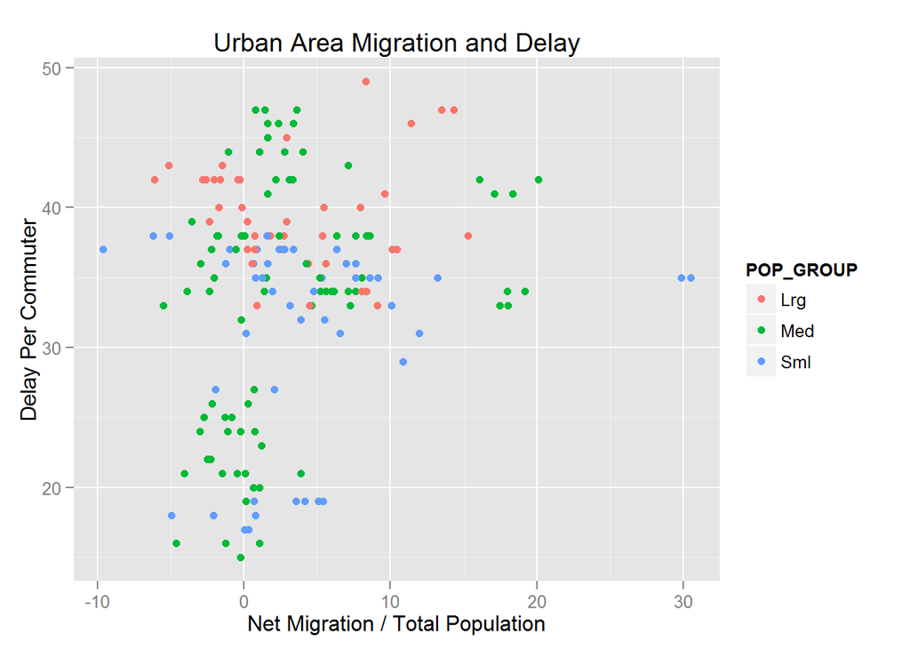

```r
source("../03 Visualizations/Plot1.R",echo=TRUE)
```

Next, we did an full join with a different visualization. Here, we plotted gas prices vs. migration per capita. There was an interesting correlation here: areas with either very high or very low (negative) migration had central gas prices, while areas with stable populations had a much higher variance in gas prices, either very expensive or very cheap.

```
##
## > require("jsonlite")
##
## > require("RCurl")
##
## > require("extrafont")
##
## > require("ggplot2")
##
## > require("dplyr")
##
## > cbsa <- data.frame(fromJSON(getURL(URLencode("129.152.144.84:5001/rest/native/?query=\"select * from trafficshort\""),
## +     httpheader = c(DB = "j ..." ... [TRUNCATED]
##
## > traffic <- data.frame(fromJSON(getURL(URLencode("129.152.144.84:5001/rest/native/?query=\"select * from cbsa\""),
## +     httpheader = c(DB = "jdbc:o ..." ... [TRUNCATED]
##
## > combinedDF <- full_join(traffic, cbsa, by = "URBAN_AREA") %>%
## +     filter(POP_GROUP %in% c("Sml", "Med", "Lrg"))
```

```
##
## > ggplot() + coord_cartesian() + scale_x_continuous() +
## +     scale_y_continuous() + labs(title = "title") + labs(x = "Migration",
## +     y = paste(" ..." ... [TRUNCATED]
```

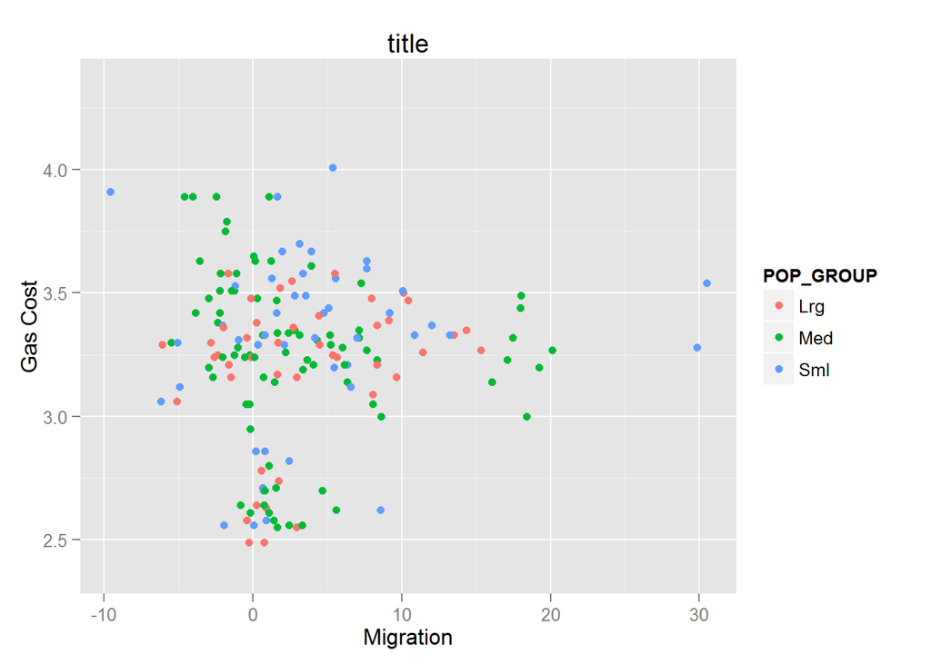

```r
source("../03 Visualizations/Plot2.R",echo=TRUE)
```

Finally, we used a left join our data with a different visualization. Here, we plotted births per capita on the x-axis and commuter stress index" on the y-axis. Maybe locations with high birth rates also have bad traffic? After visualizing the data, however, one can see that there is little or no correlation.

```
##
## > require("jsonlite")
##
## > require("RCurl")
##
## > require("extrafont")
##
## > require("ggplot2")
##
## > require("dplyr")
##
## > df1 <- data.frame(fromJSON(getURL(URLencode("129.152.144.84:5001/rest/native/?query=\"select * from trafficshort\""),
## +     httpheader = c(DB = "jd ..." ... [TRUNCATED]
##
## > df2 <- data.frame(fromJSON(getURL(URLencode("129.152.144.84:5001/rest/native/?query=\"select * from cbsa\""),
## +     httpheader = c(DB = "jdbc:oracl ..." ... [TRUNCATED]
##
## > df3 <- left_join(df1, df2, by = "URBAN_AREA") %>%
## +     filter(POP_GROUP %in% c("Med", "Lrg", "Vlg"))
```

```
##
## > ggplot() + coord_cartesian() + scale_x_continuous() +
## +     scale_y_continuous() + labs(title = "Commuter Stress and High Growth Cities") +
## +      .... [TRUNCATED]
```

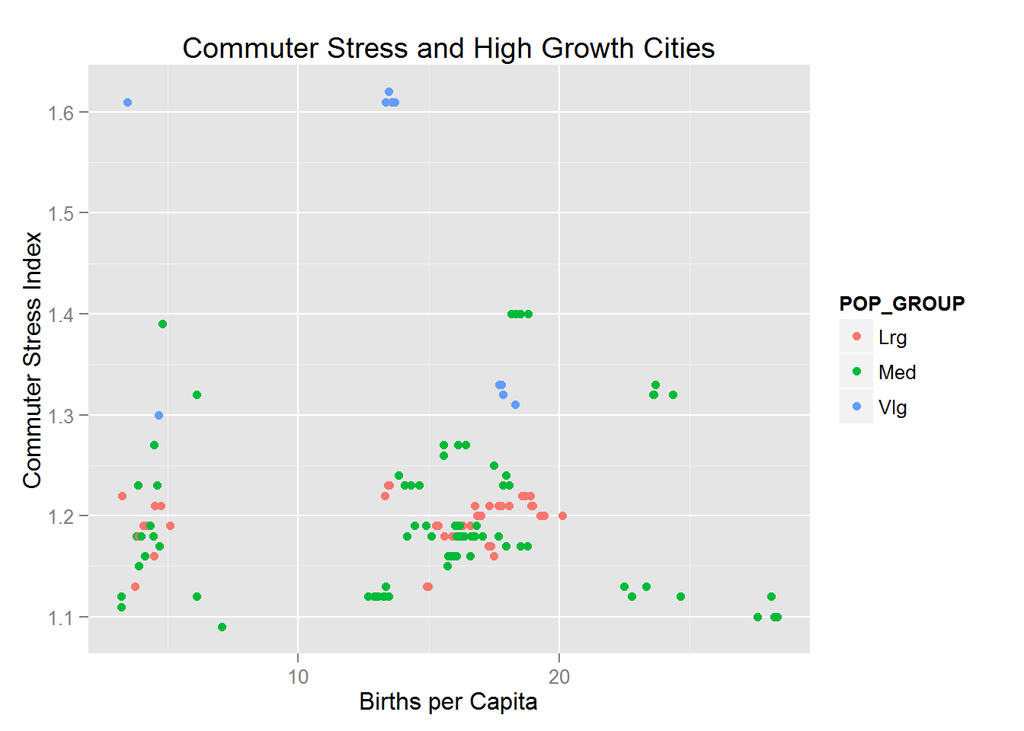

```r
source("../03 Visualizations/Plot3.R",echo=TRUE)
```